# Part II - Factors Affecting BorrowerRate on Loans

## by Halima Nasula Merenga

## Investigation Overview

> In this investigation, I wanted to look at the factors affecting Borrower Rate, specifically credit score, loan term , employment status duration and DTI ratio

## Dataset Overview

> This data set contains 113,937 loans with 81 variables, which has been cut down to 93510 rows and 19 columns after preliminary wrangling.

## Distribution of Borrower Rate

> The BorrowerRate is the The Borrower's interest rate for this loan. The histogram can be said to be bimodal with 1 peak at around 0.15 and the other at around 0.32. It is slightly right skewed with a sudden steep increase at around 0.32

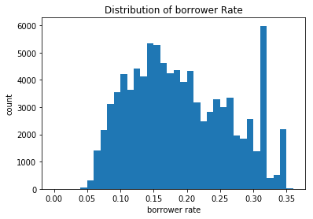

## Borrower Rate against Credit Score

> Plotting a box plot for the categorical credit score data against the Borrower Rate, we see an inverse correlation between the two. For poor credit score, the borrowerRate is highest while for the excellent credit score, the Borrower Rate is lowest.

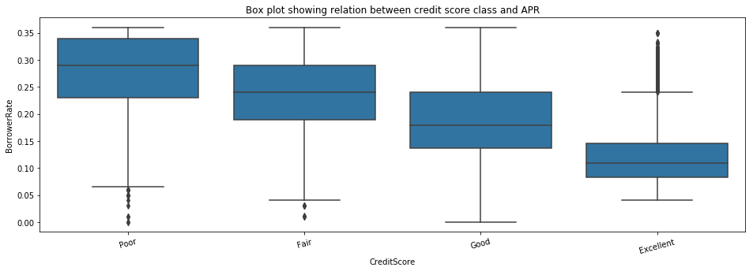

### Borrower Rate Vs. Loan Term

> The loan interest is highest for Long Term Loans and Lowest for short term goals. This is possibly because shorter terms guarantee the lender will have their money back sooner, so there’s less risk.

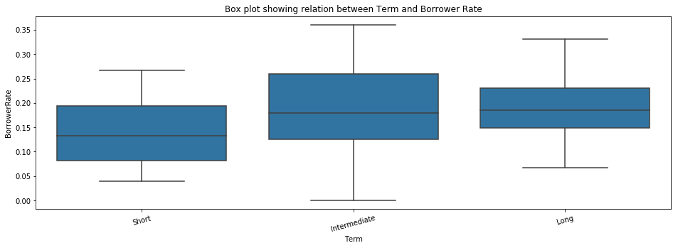

### Borrower Rate Against Employment Status Duration

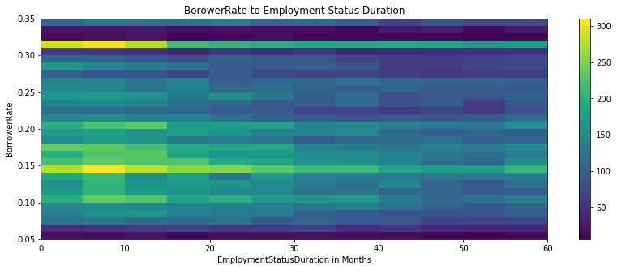

### BorrowerRate Against Debt-to-Income Ratio

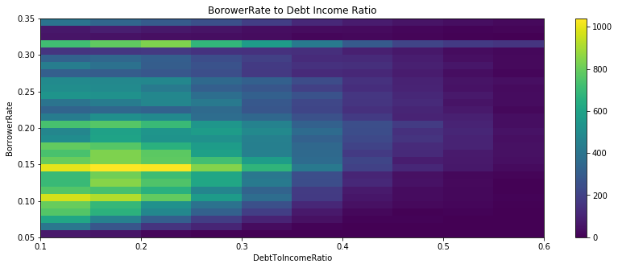

### Borrower Rate against Credit Score for each loan Term

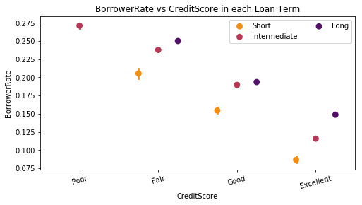